# Vignette: Basic Robust Estimators

## 5 *M*-Estimation

### 5.1 Bare-bone methods

The bare-bone methods are:

| `weighted_mean_huber()` | `weighted_total_huber()` |
| --- | --- |
| `weighted_mean_tukey()` | `weighted_total_tukey()` |

The estimators with postfix `_huber` and `_tukey` are based on, respectively, the Huber and Tukey (biweight) $\psi$-function.

**IMPORTANT**

Two *types* of *M*-estimators are available:

- `type = "rwm"`: robust weighted mean estimator
- `type = "rht"`: **robust Horvitz-Thompson estimator** of Hulliger (1995) $\rightarrow$ **separate vignette**

The robust Horvitz-Thompson estimator (`type = "rht"`) is the method of choice for pps designs (i.e., designs without replacement where the sample inclusion probabilities are proportional to some measure of size). For equal-probability designs, the *M*-estimator of `type = "rwm"` tends to be superior.

```r
> weighted_mean_huber(los, weight, type = "rwm", k = 8)
[1] 11.17228
```

**Good to know.**

In general, the tuning constant `k` must be chosen larger than (loosely speaking) “we are used to choose it” in “classical” robust statistic. More precisely, in the context of an *infinite population* with a standard *Gaussian* distribution, the constant $k = 1.345$ ensures that the Huber *M*-estimator of location achieves 95% efficiency compared with the arithmetic mean under the Gaussian model. The efficiency considerations underlying the choice of $k = 1.345$ *do not* carry over to distributions other than the Gaussian.

The *M*-estimators are computed by iterative methods. If the algorithm fails to converge, the functions return `NA`. By default, the algorithm uses a maximum of `maxit = 50` iterations and a numerical tolerance criterion of `tol = 1e-5` as a stopping rule. Other values of `maxit` and `tol` can be specified in the function call.

The function `huber2()` is an implementation of the weighted Huber proposal 2 estimator. It is only available as bare-bone method.<sup>Note 3</sup>

```r
> huber2(los, weight, k = 8)
[1] 13.02817
```

### 5.2 Survey methods

The survey methods are:

| `svymean_huber()` | `svytotal_huber()` |
| --- | --- |
| `svymean_tukey()` | `svytotal_tukey()` |

The Huber *M*-estimator of the mean (and its standard error) can be computed with

```r
> m <- svymean_huber(~los, dn, type = "rwm", k = 8)
> m
     mean    SE
los 11.17 1.328
```

The `summary()` method summarizes the most important facts about the *M*-estimate

```r
> summary(m)
Huber M-estimator (type = rwm) of the population mean

     mean    SE
los 11.17 1.328

Robustness:
  Psi-function: with k = 8
  mean of robustness weights: 0.9877

Algorithm performance:
  converged in 4 iterations
  with residual scale (weighted MAD): 5.93

Sampling design:
Independent Sampling design
svydesign(ids = ~1, fpc = ~fpc, weights = ~weight, data = losdata)
```

The estimated scale (weighted MAD) can be extracted with the `scale()` function. Additional utility functions are `coef()`, `vcov()`, `SE()`, `residuals()`, `fitted()`, and `robweights()`. The following figure shows a plot of the robustness weights against the residuals. We see that large residuals are downweighted.

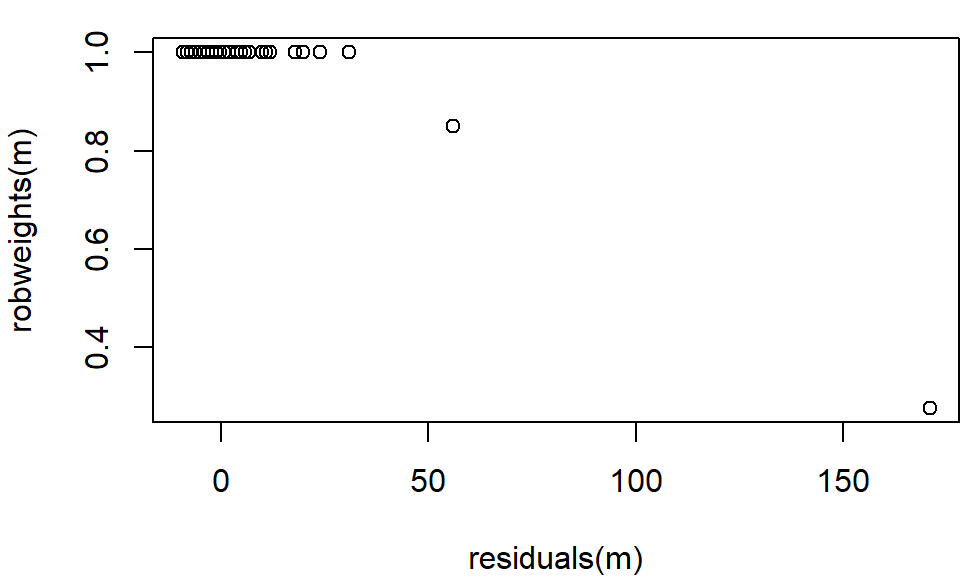

```r
> plot(residuals(m), robweights(m))
```

### 5.3 Adaptive estimation

An adaptive *M*-estimator of the total (or mean) is defined by letting the data chose the tuning constant $k$. Let $\widehat{T}$ denote the weighted total, and let $\widehat{T}_k$ be the Huber *M*-estimator of the weighted total with robustness tuning constant $k$. Under quite general regularity conditions, the estimated mean square error (MSE) of $\widehat{T}_k$ can be approximated by (see e.g., Gwet and Rivest, 1992; Hulliger, 1995)

$$\widehat{\mathrm{mse}}\big(\widehat{T}_{k}\big) \approx \mathrm{var}\big(\widehat{T}_{k}\big) +\big(\widehat{T} - \widehat{T}_{k}\big)^2.$$

The minimum estimated risk (MER) estimator (Hulliger, 1995) selects $k$ such that $\widehat{\mathrm{mse}}\big(\widehat{T}_{k}\big)$ is minimal (among all candidate estimators). Now, suppose that we have been working on the *M*-estimator with $k=8$.

```r
> m <- svymean_huber(~los, dn, type = "rwm", k = 8)
```

Next, we compute the MER, starting from the current *M*-estimate, i.e., object `m`.

```r
> mer(m)
Search interval: [1, 10]
Minimum found for k =  10
Rel. efficiency gain: 35%
     mean    SE
los 11.46 1.478
```

Hence, the MER is 35% more efficient than the classical estimator as an estimator of the population total.

## 6 Utility Functions

### 6.1 Weighted quantile and median

The weighted quantile (and median) can be computed by

```r
> weighted_quantile(los, weight, probs = c(0.1, 0.9))
10% 90%
  3  22
> weighted_median(los, weight)
50%
  8
```

When all weights are equal, `weighted_quantile()` is equal to `base::quantile()` with argument `type = 2`.

### 6.2 Weighted MAD: median absolute deviation

The normalized weighted median absolute deviations about the weighted median can be computed with

```r
> weighted_mad(los, weight)
[1] 5.930408
```

By default, the normalization constant to make the weighted MAD an unbiased estimator of scale at the Gaussian core model is `constant = 1.482602`. This constant can be changed if necessary.

### 6.3 Weighted IQR: interquartile range

The normalized weighted interquartile range can be computed with

```r
> weighted_IQR(los, weight)
[1] 6.6717
```

By default, the normalization constant to make the weighted IQR an unbiased estimator of scale at the Gaussian core model is `constant = 0.7413`. This constant can be changed if necessary.

## Notes

<sup>2</sup> We have constructed the `losdata` as a showcase; though, the LOS measurements are real data that we have taken from the $201$ observations in Ruffieux et al. (2000). Our `losdata` are a sample of size $n = 70$ from the $201$ original observations.

<sup>3</sup> The function `huber2()` is is similar to `MASS::hubers()` (Venables and Ripley, 2002). It differs from the implementation in `MASS` in that it allows for weights and is initialized by the (normalized) weighted interquartile range (IQR) not the median absolute deviations (MAD).

## Bibliographical notes

The paper of Chambers (1986) is the landmark paper about outliers in finite population sampling. Lee (1995) and Beaumont and Rivest (2009) are a good starting point to learn about robustness in finite population sampling.

Trimming and winsorization are discussed in Lee (1995) and Beaumont and Rivest (2009). The variance estimators of the weighted trimmed and winsorized estimators are straightforward adaptions of the classical estimators; see Huber and Ronchetti (2009, Chap. 3.3) or Serfling (1980, Chap. 8). A rigorous treatment in the context of finite population sampling can be found in Shao (1994).

Rao (1971) was among the first to propose weight reduction. Consider a sample of size $n$, and suppose that the $i$th observation is an outlier. He suggested to reduce the outlier’s sampling weight $w_i$ to one, and redistribute the weight difference $w_i−1$ among the remaining observations. As a result, observation $i$ does not represent other values like it. Dalén’s estimator offers a more general notion of weight reducution; see Dalén (1987) and also Chen et al. (2017).

## References

BEAUMONT, J.-F. AND RIVEST, L.-P. (2009). Dealing with outliers in survey data. In: *Sample Surveys: Theory, Methods and Inference* ed. by Pfeffermann, D. and Rao, C. R. Volume 29A of Handbook of Statistics, Amsterdam: Elsevier, Chap. 11, 247–280. DOI: 10.1016/S0169-7161(08)00011-4

CHAMBERS, R. (1986). Outlier Robust Finite Population Estimation. *Journal of the American Statistical Association* **81**, 1063–1069, [DOI: 10.1080/01621459.1986.10478374](https://doi.org/10.1080/01621459.1986.10478374).

DALEN, J. (1987). *Practical Estimators of a Population Total Which Reduce the Impact of Large Observations*. Research report, Statistics Sweden, Stockholm.

CHEN, Q., ELLIOTT, M. R., HAZIZA, D., YANG, Y., GHOSH, M., LITTLE, R. J. A., SEDRANSK, J. AND THOMPSON, M. (2017). Approaches to Improving Survey-Weighted Estimates. *Statistical Science* **32**, 227–248, [DOI: 10.1214/17-STS609](https://doi.org/10.1214/17-STS609).

GWET, J.-P. AND RIVEST, L.-P. (1992). Outlier Resistant Alternatives to the Ratio Estimator. *Journal of the American Statistical Association* **87**, 1174–1182, [DOI: 10.1080/01621459.1992. 10476275](https://doi.org/10.1080/01621459.1992.10476275).

HUBER, P. J. AND RONCHETTI, E. (2009). *Robust Statistics*, New York: John Wiley & Sons, 2nd edition, [DOI: 10.1002/9780470434697](https://doi.org/10.1002/9780470434697).

HULLIGER, B. (2006). Horvitz–Thompson Estimators, Robustified. In: *Encyclopedia of Statistical Sciences* ed. by Kotz, S. Volume 5, Hoboken (NJ): John Wiley & Sons, 2nd edition, [DOI: 10.1002/0471667196.ess1066.pub2](https://doi.org/10.1002/0471667196.ess1066.pub2).

HULLIGER, B. (1999). Simple and robust estimators for sampling. In: *Proceedings of the Survey Research Methods Section*, American Statistical Association, 54–63, American Statistical Association.

HULLIGER, B. (1995). Outlier Robust Horvitz–Thompson Estimators. *Survey Methodology* **21**, 79–87.

LEE, H. (1995). Outliers in business surveys. In: *Business survey methods* ed. by Cox, B. G., Binder, D. A., Chinnappa, B. N., Christianson, A., Colledge, M. J. and Kott, P. S. New York: John Wiley & Sons, Chap. 26, 503–526, [DOI: 10.1002/9781118150504.ch26](https://doi.org/10.1002/9781118150504.ch26).

LUMLEY, T. (2021). survey: analysis of complex survey samples. R package version 4.0, URL https://CRAN.R-project.org/package=survey.

LUMLEY, T. (2010). *Complex Surveys: A Guide to Analysis Using R: A Guide to Analysis Using R*, Hoboken (NJ): John Wiley & Sons.

RAO, J. N. K. (1971). Some Aspects of Statistical Inference in Problems of Sampling from Finite Populations. In: *Foundations of Statistical Inference* ed. by Godambe, V. P. and Sprott, D. A. Toronto: Holt, Rinehart, and Winston, 171–202.

ROYALL, R. M. AND CUMBERLAND, W. G. (1981). An Empirical Study of the Ratio Estimator and Estimators of its Variance. *Journal of the American Statistical Association* **76**, 66–82, [DOI: 10.2307/2287043](https://doi.org/10.2307/2287043).

RUFFIEUX, C., PACCAUD, F. AND MARAZZI, A. (2000). Comparing rules for truncating hospital length of stay. *Casemix Quarterly* **2**, 3–11.

SHAO, J. (1994). L-Statistics in complex survey problems. *The Annals of Statistics* **22**, 946–967, [DOI: 10.1214/aos/1176325505](https://doi.org/10.1214/aos/1176325505).

SERFLING, R. J. (1980). *Approximation theorems of mathematical statistics*, New York: John Wiley & Sons. [DOI: 10.1002/9780470316481](https://doi.org/10.1002/9780470316481).

VENABLES, W. N. AND RIPLEY, B. D. (2002). *Modern Applied Statistics with S*, New York: Springer-Verlag, 4th edition, [DOI: 10.1007/978-0-387-21706-2](https://doi.org/10.1007/978-0-387-21706-2).